# Assignment #1 - Data set selection and initial Processing

Jerrie Feng

## Download Data

```r
#Install necessary packages if not already

if (!requireNamespace("GEOmetadb", quietly = TRUE)) {
  BiocManager::install("GEOmetadb")
}
```

```
## Setting options('download.file.method.GEOquery'='auto')
```

```
## Setting options('GEOquery.inmemory.gpl'=FALSE)
```

```r
if (!requireNamespace("GEOquery", quietly = TRUE)) {
  BiocManager::install("GEOquery")
}
if (!requireNamespace("BiocManager", quietly = TRUE)){
  install.packages("BiocManager")
  BiocManager::install("edgeR")
  BiocManager::install("biomaRt")
}
if (! requireNamespace("Biobase", quietly = TRUE)) {
  BiocManager::install("Biobase")
}
if (! requireNamespace("readr", quietly = TRUE)) {
  BiocManager::install("readr")
}

#if(!file.exists('GEOmetadb.sqlite')) GEOmetadb::getSQLiteFile()
```

```r
#Use the GEOquery Bioconductor package to download
#Only download if needed

if (!file.exists("GSE135448.rds")) {

  #Download files from GEO
  GEOfolder <- paste0("./", "GSE135448") ###
  supfiles <- GEOquery::getGEOSuppFiles("GSE135448")

  # Save rds
  saveRDS(object = supfiles, file = "GSE135448.rds")

} else {
  supfiles <- readRDS("GSE135448.rds")
}


# Use the 'counts' file
files <- rownames(supfiles)
data <- read.delim(files[2],header=TRUE, check.names = FALSE)
```

## Assess Data

```r
#Obtain the description for our data
infoGSE <- GEOquery::getGEO("GSE135448", GSEMatrix=FALSE)
```

[output not shown]

[output not shown]

[output not shown]

[output not shown]

[output not shown]

[output not shown]

[output not shown]

[output not shown]

[output not shown]

[output not shown]

[output not shown]

[output not shown]

[output not shown]

[output not shown]

[output not shown]

[output not shown]

[output not shown]

[output not shown]

[output not shown]

[output not shown]

[output not shown]

[output not shown]

[output not shown]

[output not shown]

[output not shown]

```r
#Sort the samples into 2 diets
highprotein <- data[2:10]
rownames(highprotein) <- data[,1]
lowprotein <- data[11:20]
rownames(lowprotein) <- data[,1]
```

## Clean Data

We want to filter out the low counts and remove duplicates. We also want to plot the data to get more information.

```r
#Genes count
dim(data)[1]
```

```
## [1] 28517
```

```r
#Remove the low counts with edgeR
cpmData <- edgeR::cpm(data[2:19])
rownames(cpmData) <- data[,1]

keep <- rowSums(cpmData >1) >=10
filterData = data[keep,]

repeated <- filterData[duplicated(rownames(filterData)), ]

#Check for duplicates
dim(filterData[duplicated(filterData$genesymbol),])[1]
```

```
## [1] 0
```

```r
#Gene count after filter
dim(filterData)[1]
```

```
## [1] 13369
```

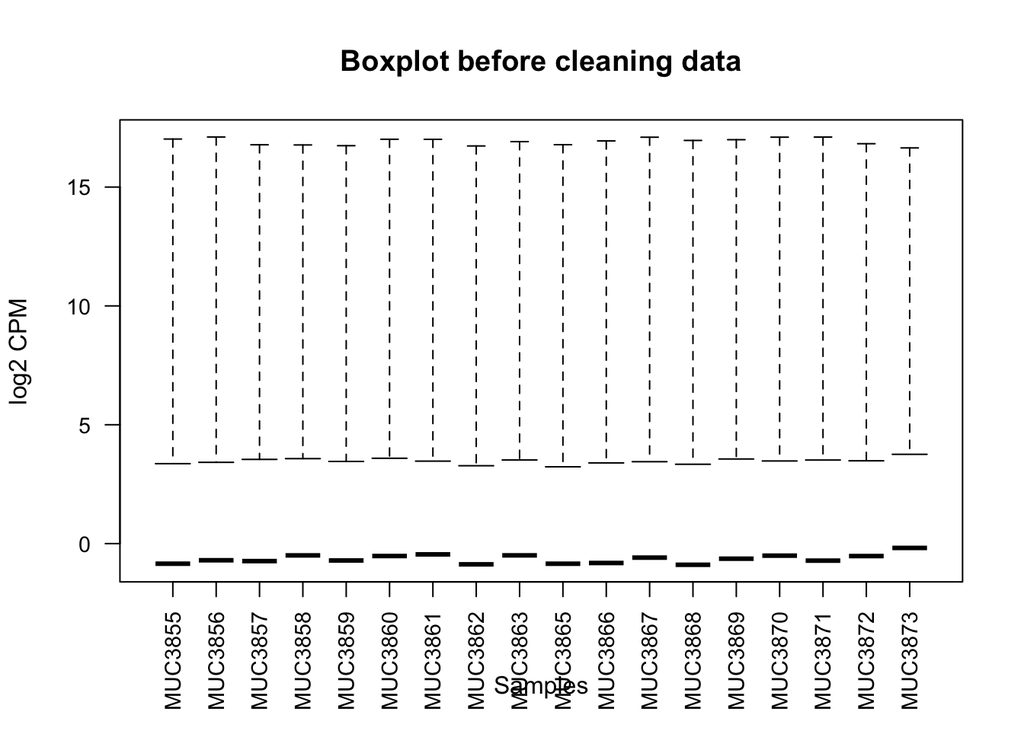

```r
#Visualizing the data

#Boxplot for using uncleaned data counts
boxplot(log2(edgeR::cpm(data[,2:19])), xlab = "Samples", ylab = "log2 CPM", las=2, cex.axis=0.9,
        main="Boxplot before cleaning data")
```

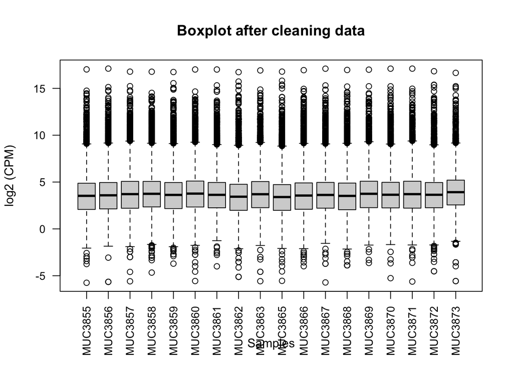

```r
#Boxplot for using cleaned data counts
boxplot(log2(edgeR::cpm(filterData[,2:19])), xlab = "Samples", ylab = "log2 (CPM)", las=2, cex.axis=0.9,
        main="Boxplot after cleaning data")
```

## Map to HUGO

This data actually provided the HGNC gene symbols, so there’s no need to convert. However, we will check it again to see if any do not match the HUGO format.

```r
#Let's get the HGNC symbols and see how many of them matched to a gene symbol
ensembl <- biomaRt::useMart("ensembl")
ensembl_haspiens <- biomaRt::useDataset("hsapiens_gene_ensembl", mart=ensembl)
```

```
## Ensembl site unresponsive, trying asia mirror
```

```r
symbolMatch <- biomaRt::getBM(attributes = "hgnc_symbol",
   filters = c("hgnc_symbol"),
   values = data$genesymbol,
   mart = ensembl_haspiens)

# Check the percentage unmatched
unmatch <- 1-dim(symbolMatch)[1]
percent <- (unmatch / dim(filterData)[1])*100
```

From the calculation, we see that around 26.95% of the given gene symbols are not in the expected HUGO format. However, there doesn’t seem to be a way to match the old symbols, but they can still be found in the HUGO database.

## Normalization

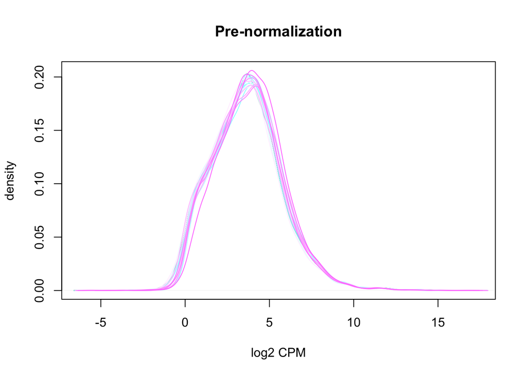

```r
matrix <- as.matrix(filterData[,2:19])
rownames(matrix) <- filterData$hgnc_symbol
dValue <- edgeR::DGEList(counts=matrix, group=c(colnames(filterData)[2:19]))

#Get normalization factors
dValue <- edgeR::calcNormFactors(dValue)
normData <- edgeR::cpm(dValue)

#Pre-normalization
density <- apply(log2(edgeR::cpm(filterData[2:19])), 2, density)

xl <- 0
yl <- 0
for (i in 1:length(density)) {
  xlim <- range(c(xl, density[[i]]$x))
  ylim <- range(c(yl, density[[i]]$y))
}

plot(density[[1]], xlim=xlim, ylim=ylim, ylab="density", xlab = "log2 CPM", main="Pre-normalization")
dCol<- cm.colors(length(density))
for (i in 1:length(density)){
  lines(density[[i]], col=dCol[i])
}
```

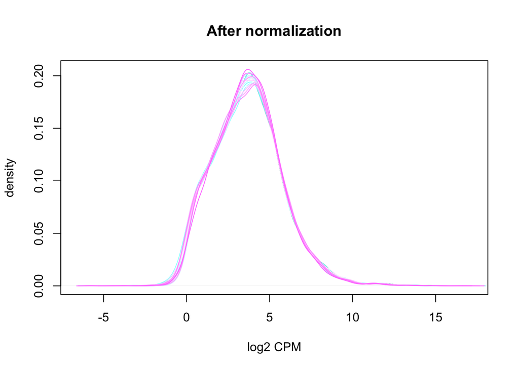

```r
#After normalization
densityNorm <- apply(log2(normData), 2, density)

xl <- 0
yl <- 0
for (i in 1:length(densityNorm)) {
  xlim <- range(c(xl, densityNorm[[i]]$x))
  ylim <- range(c(yl, densityNorm[[i]]$y))
}

plot(densityNorm[[1]], xlim=xlim, ylim=ylim, ylab="density", xlab = "log2 CPM", main="After normalization")
dCol<- cm.colors(length(densityNorm))
for (i in 1:length(densityNorm)){
  lines(densityNorm[[i]], col=dCol[i])
}
```

## Document Questions

1. What are the control and test conditions of the dataset?

This was a Randomized Controlled Trial (RCT) in which 19 patients with obesity undergoing bariatric surgery were randomized into 2 diet groups, a low protein (10E% protein) and a high protein (30E% protein), for three weeks prior to surgery. We are testing/comparing the RNA-seq analyses performed on liver samples (Intrahepatic lipid levels (IHL) and serum fibroblast growth factor 21 (FGF21)).

2. Why is the dataset of interest to you?

I’m interested in this dataset because I’m interested in nutrition and its impact on our health.

3. Were there expression values that were not unique for specific genes? How did you handle these?

There were not any, but there were some with too low values, and I did not include these.

4. Were there expression values that could not be mapped to current HUGO symbols?

Yes, there was 26.95% of the values that couldn’t be mapped.

5. How many outliers were removed?

Based on the boxplot, it can be seen that the only those lower than 1 cpm, with a threshold of 10, were removed.

6. How did you handle replicates?

I filtered through

7. What is the final coverage of your dataset?

13369